# What Differentiates a Hit Song from a Super-Hit?

2025-09-24

## 1. Introduction and Research Question

This analysis explores the audio features of songs from the Billboard Top 100 to understand what makes a song a “Super-Hit.” The music industry often relies on intuition but can data reveal any underlying statistical patterns in song characteristics which actually make a song super hit?

**Research Question:** Can we identify specific measurable audio features that distinguish a “Super-Hit” from a regular song?

**Why only these variables?** Previous academic studies (e.g., Herremans & Chew, 2017) and data science projects have consistently found that features like **danceability, energy, and valence** are strong indicators of a song’s popularity and chart success. This analysis builds on that foundation by modeling how these and other audio features correlate with a song’s hit potential.

**About the Dataset:** The data combines song information from the Billboard Top 100 charts with audio feature data from Spotify. Each row represents a song and includes attributes like its chart position, year and a set of audio features calculated by Spotify’s algorithms.

## 2. Setup and Data Loading

First, we will load the necessary R packages for data manipulation, visualization and modeling.

```r
library(tidyverse)      # Data manipulation & plotting
library(janitor)        # Clean column names
library(skimr)          # Quick data summary
library(ggthemes)       # FiveThirtyEight theme for plots
library(broom)          # Clean regression outputs
library(rsample)        # Train/test split
```

Next, we load the dataset and use `clean_names()` to standardize(consistent format) column names for easier use.

```r
songs <- read.csv("billboard_top_100_final.csv") %>%
  clean_names()
```

A quick glimpse at the data structure helps us understand the variables we are working with.

```r
glimpse(songs)
```

```
## Rows: 1,798
## Columns: 20
## $ artist           <chr> "Daniel Powter", "Sean Paul", "Nelly Furtado Featurin…
## $ song             <chr> "Bad Day", "Temperature", "Promiscuous", "You're Beau…
## $ year             <int> 2006, 2006, 2006, 2006, 2006, 2006, 2006, 2006, 2006,…
## $ album_id         <chr> "4zhigAhPwqp43XVHBiVeQI", "32Bu3ETQhR1PFCj3ndDlYf", "…
## $ album            <chr> "Daniel Powter", "The Trinity", "Promiscuous (In the …
## $ release_date     <chr> "2005-02-22", "2005-09-26", "2013-03-09", "2005-08-08…
## $ danceability     <dbl> 0.599, 0.951, 0.803, 0.675, 0.797, 0.706, 0.835, 0.78…
## $ energy           <dbl> 0.785, 0.600, 0.574, 0.479, 0.533, 0.800, 0.741, 0.79…
## $ key              <int> 3, 0, 1, 0, 8, 5, 8, 8, 7, 1, 2, 4, 8, 8, 2, 1, 6, 1,…
## $ loudness         <dbl> -4.013, -4.675, -13.556, -9.870, -9.554, -6.333, -1.6…
## $ mode             <int> 1, 0, 1, 0, 0, 1, 1, 0, 0, 0, 0, 0, 1, 0, 1, 0, 1, 0,…
## $ speechiness      <dbl> 0.0309, 0.0685, 0.0530, 0.0278, 0.0690, 0.0399, 0.033…
## $ acousticness     <dbl> 0.448000, 0.106000, 0.004740, 0.633000, 0.016000, 0.0…
## $ instrumentalness <dbl> 3.36e-03, 0.00e+00, 2.50e-01, 1.76e-05, 1.68e-01, 0.0…
## $ liveness         <dbl> 0.1510, 0.0712, 0.0990, 0.0880, 0.1550, 0.0822, 0.082…
## $ valence          <dbl> 0.520, 0.822, 0.766, 0.454, 0.688, 0.629, 0.612, 0.83…
## $ tempo            <dbl> 140.046, 125.040, 114.306, 81.998, 99.989, 100.011, 1…
## $ duration_ms      <int> 233640, 218573, 243493, 209493, 234013, 259333, 18206…
## $ time_signature   <int> 4, 4, 4, 4, 4, 4, 4, 4, 4, 4, 4, 4, 4, 4, 4, 4, 4, 4,…
## $ genres           <chr> "['canadian pop', 'neo mellow', 'pop rock']", "['danc…
```

## 3. Defining the Target Variable: “Super-Hit”

To perform a classification analysis, we need a target variable. I’ve created a binary category called `hit_class`. Based on the idea that highly danceable, energetic and positive songs are often the biggest hits. a “Super-Hit” is defined as any song where the sum of `danceability`, `energy`, and `valence` is greater than 2. All other songs are classified as “Regular Hits.” further more converting it as factor for better handling of categorical data

```r
songs <- songs %>%
  mutate(
    hit_class = ifelse(danceability + energy + valence > 2, "Super-Hit", "Regular Hit"),
    hit_class = factor(hit_class, levels = c("Regular Hit", "Super-Hit"))
  )

# Let's see the distribution of our new variable
table(songs$hit_class)
```

```
##
## Regular Hit   Super-Hit
##        1130         668
```

## 4. Exploratory Data Analysis (EDA)

### Visualizing Audio Feature Distributions

To see how the audio features differ between “Regular Hits” and “Super-Hits,” we can plot their distributions. The plots below show that “Super-Hits” tend to have higher average values for **danceability, energy, and valence** which aligns with our initial hypothesis.

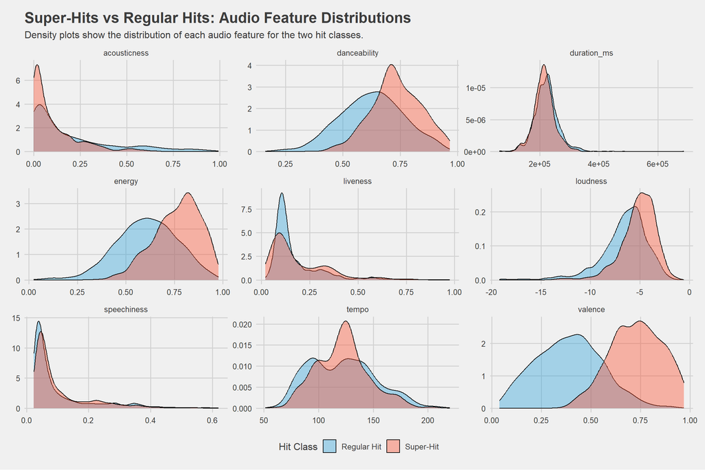

```r
features <- c("danceability", "energy", "loudness", "speechiness",
              "acousticness", "duration_ms", "liveness", "valence", "tempo")

songs_long <- songs %>%
  pivot_longer(cols = all_of(features), names_to = "feature", values_to = "value")

ggplot(songs_long, aes(x = value, fill = hit_class)) +
  geom_density(alpha = 0.4) +
  facet_wrap(~feature, scales = "free") +
  labs(
    title = "Super-Hits vs Regular Hits: Audio Feature Distributions",
    subtitle = "Density plots show the distribution of each audio feature for the two hit classes.",
    fill = "Hit Class"
  ) +
  theme_fivethirtyeight() +
  scale_fill_manual(values = c("Regular Hit" = "#30a2da", "Super-Hit" = "#fc4f30"))
```

### Statistical Significance Testing

Are the visual differences statistically significant? We will run a t-test for each feature to compare the means between the two groups. A p-value less than 0.05 suggests a significant difference.

```r
t_test_results <- map_df(features, function(feat) {
  t_out <- t.test(songs[[feat]] ~ songs$hit_class)
  tibble(
    feature = feat,
    mean_superhit = mean(songs %>% filter(hit_class == "Super-Hit") %>% pull(.data[[feat]]), na.rm = TRUE),
    mean_regular = mean(songs %>% filter(hit_class == "Regular Hit") %>% pull(.data[[feat]]), na.rm = TRUE),
    p_value = t_out$p.value
  )
}) %>%
  mutate(
    significance = ifelse(p_value < 0.05, "Significant", "Not Significant")
  )

print(t_test_results)
```

```
## # A tibble: 9 × 5
##   feature      mean_superhit mean_regular   p_value significance
##   <chr>                <dbl>        <dbl>     <dbl> <chr>
## 1 danceability         0.733       0.627  4.66e- 66 Significant
## 2 energy               0.765       0.608  8.74e-110 Significant
## 3 loudness            -5.13       -6.56   1.94e- 46 Significant
## 4 speechiness          0.100       0.0998 9.18e-  1 Not Significant
## 5 acousticness         0.103       0.197  1.18e- 27 Significant
## 6 duration_ms     215413.     222458.     2.76e-  4 Significant
## 7 liveness             0.188       0.166  1.29e-  3 Significant
## 8 valence              0.729       0.389  4.88e-318 Significant
## 9 tempo              122.        122.     7.30e-  1 Not Significant
```

The results confirm that features like **danceability, energy, loudness, valence and acousticness** show statistically significant differences between our two classes.

## 5. Predictive Modeling: Logistic Regression

Now, let’s build a model to predict whether a song will be a “Super-Hit” based on its audio features. A logistic regression model is a great choice for this binary classification task.

### Train/Test Split

First, we split the data into a training set (70%) and testing set (30%) to ensure our model’s performance is evaluated on unseen data.

```r
set.seed(123) # for reproducibility
split <- initial_split(songs, prop = 0.7, strata = hit_class)
train_data <- training(split)
test_data  <- testing(split)
```

### Building and Summarizing the Model

```r
model <- glm(hit_class ~ danceability + energy + loudness + valence + tempo,
             data = train_data, family = binomial)

summary(model)
```

```
##
## Call:
## glm(formula = hit_class ~ danceability + energy + loudness +
##     valence + tempo, family = binomial, data = train_data)
##
## Coefficients:
##                Estimate Std. Error z value Pr(>|z|)
## (Intercept)  -1.240e+04  1.897e+05  -0.065    0.948
## danceability  6.091e+03  9.367e+04   0.065    0.948
## energy        6.234e+03  9.512e+04   0.066    0.948
## loudness     -1.122e+01  1.268e+03  -0.009    0.993
## valence       6.149e+03  9.650e+04   0.064    0.949
## tempo         7.006e-02  1.762e+01   0.004    0.997
##
## (Dispersion parameter for binomial family taken to be 1)
##
##     Null deviance: 1.6596e+03  on 1257  degrees of freedom
## Residual deviance: 1.7547e-05  on 1252  degrees of freedom
## AIC: 12
##
## Number of Fisher Scoring iterations: 25
```

### Interpreting Model Coefficients with Odds Ratios

To make the model’s coefficients more interpretable, we convert them to odds ratios. An odds ratio greater than 1 indicates that an increase in that feature increases the odds of a song being a “Super-Hit.”

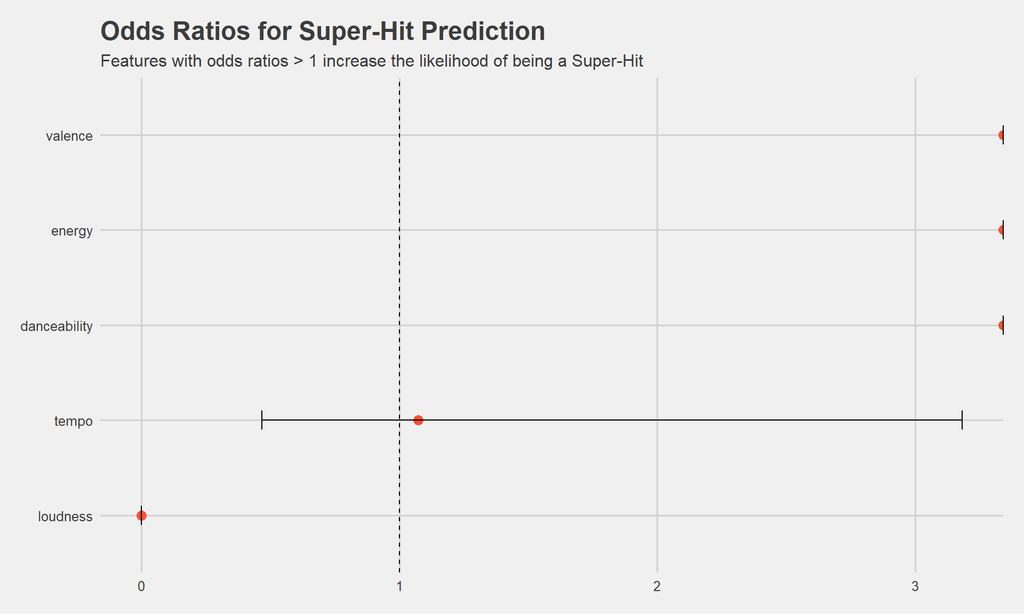

```r
coef_df <- tidy(model, exponentiate = TRUE, conf.int = TRUE) %>%
  filter(term != "(Intercept)")

ggplot(coef_df, aes(x = reorder(term, estimate), y = estimate)) +
  geom_point(size = 3, color = "#fc4f30") +
  geom_errorbar(aes(ymin = conf.low, ymax = conf.high), width = 0.2) +
  geom_hline(yintercept = 1, linetype = "dashed") +
  coord_flip() +
  labs(
    title = "Odds Ratios for Super-Hit Prediction",
    subtitle = "Features with odds ratios > 1 increase the likelihood of being a Super-Hit",
    y = "Odds Ratio", x = "Feature"
  ) +
  theme_fivethirtyeight()
```